# Parasite Comparison

Eddy Dowle

11/16/2018

# To get the files there are three options:

# Option one: full download from the web

This is the most data rich option, it will bring down keywords, abstracts, citation information, country of origin etc

1. Go to the WoS website put in search
2. Note down the total number of searches returned
3. Hit add to marked list on first seach return page
4. Put in 1 : ‘to the total number of searches returned’ to save them all
5. Select marked list on the top left (should now have the number of records saved)
6. Step 1 select the span of records to download 1:500, 501:1000 etc etc (500 at a time)
7. Step 2 on output options choose ‘select all’ for information brought down
8. Step 3 choose save to other file formats and then select bibTex

# Option two: partial download using the api

This will bring down paper titles, keywords, author afiliations and some other metadata but not citation information or the country information. You can get citations per year from online if its less than 10000 (see below).

# Option three: broadscale metadata

You can get broad scale data from online without doing the 500 at a time-but not keywords and other metadata.

1. Put your search into Wos
2. Click the analyse tab
3. Select publication years
4. Scroll to the bottom of the page (bottom right)
5. Select all data rows (up to 200,000-this works because we are looking at dates not individual records)
6. Hit download-this will download as analyze.txt
7. Move it to the location you want for R
8. Open it in a text editor (i.e. BBEdit, TextEdit, notepad etc)
9. Change spaces to underscores and remove the random lines at the end of the file that are not data and save it under a better name
10. Go back to WoS search select countries/regions tab and repeat steps 5:9 to download a file of the papers per countries You can do a citation report and get citation per year, if its less than 10000 You cannot get keywords from this (as far as I can tell anyhow)

# Analysing data that you download 500 at a time

First up set your R up by loading the required packages and setting the working directory. Change the path in setwd to where you have saved your files.

If you failed to follow Eddy’s instructions and did not install the packages already you will need to install them also.

```r
#unhash this if you can't follow instructions
#install.packages('bibliometrix')
#install.packages('tidyverse')
#install.packages("wordcloud")
#install.packages('tm')
#install.packages('RColorBrewer')

#load packages
library(bibliometrix)
library(tidyverse)
library(wordcloud)
library(tm)
library(RColorBrewer)

setwd("~/Documents/CoAuthorMS/parasitebibsearch/parasitesonly/")
```

We are going to use the bibliometrix package to load our many files from the downloads in but first we are just going to modify a function from that package to streamline the read in of files (dont worry about what is going on here)

```r
readFilesmod<-function (...)
{
  arguments <- as.list(...)
  k = length(arguments)
  D = list()
  enc = "UTF-8"
  for (i in 1:k) {
    D[[i]] = suppressWarnings(readLines(arguments[[i]], encoding = enc))
  }
  D = unlist(D)
  return(D)
}
```

Now we are going to read our data in using the function from above. This will generate a huge character file which is horible to look at. We will use a function from the bibliometrix package to turn this into a table.

```r
file_list<-list.files(pattern='*.bib',full.names=T)
citations<-readFilesmod(dput(as.character(file_list)))
```

```
## c("./savedrecs.bib", "./savedrecs(1).bib", "./savedrecs(2).bib",
## "./savedrecs(3).bib")
```

```r
citations_df <- convert2df(citations, dbsource = "isi", format = "bibtex")
```

```
##
## Converting your isi collection into a bibliographic dataframe
##
## Articles extracted   100
## Articles extracted   200
## Articles extracted   300
## Articles extracted   400
## Articles extracted   500
## Articles extracted   600
## Articles extracted   700
## Articles extracted   800
## Articles extracted   900
## Articles extracted   1000
## Articles extracted   1100
## Articles extracted   1200
## Articles extracted   1300
## Articles extracted   1400
## Articles extracted   1500
## Articles extracted   1507
## Done!
##
##
## Generating affiliation field tag AU_UN from C1:  Done!
```

Now we have a dataframe-much easier! You can view this to see the various feilds with the authors etc.

We can also subset this dataset here: If we only wanted to look at records from 2000-2005 (year is under PY in the dataframe-publication year). Or maybe we wanted to see how long it took for 10% of the publications to be released (10% were released by 1991)

```r
citations_df_2000_2005<-citations_df %>% filter(between(PY, 2000, 2005))
citations_df %>% arrange(., PY) %>% slice(., round(nrow(citations_df)*0.1, digits = 0)) %>% select(.,PY)
```

```
##     PY
## 1 1991
```

We are going to use the function biblioanalysis to turn our dataframe into a object of various tables. None of these statistics are particularily hard to generate or special-it just does it in one hit which is nice! This function builds an object with various dataframes stored in it (23 dataframes). To access a dataframe you can call it directly. Remember you can view the help file for a function e.g. ?biblioAnalysis

This transformation drops some information so we will go back to the orginal table every now and then-depending on what we want to do.

```r
citations_ana <- biblioAnalysis(citations_df, sep = ";")
#you can call them directly with:
head(citations_ana$Years)
```

```
## [1] 2018 2018 2018 2018 2018 2018
```

```r
#Most of them are just straight forward transformation, e.g.
head(citations_ana$TotalCitation)
```

```
## [1] 0 0 0 1 0 0
```

```r
#is just this column from the orginal dataframe
head(citations_df$TC)
```

```
## [1] 0 0 0 1 0 0
```

The handy thing about turning it into a bibliometrix object is that use can use the summary function on the bibliometrix object. You can set the number of entries to return by changing the k = X

```r
citations_ana.sum <- summary(object = citations_ana, k = 10, pause = FALSE)
```

```
##
##
## Main Information about data
##
##  Documents                             1507
##  Sources (Journals, Books, etc.)       429
##  Keywords Plus (ID)                    3835
##  Author's Keywords (DE)                3011
##  Period                                1966 - 2018
##  Average citations per documents       30.1
##
##  Authors                               4639
##  Author Appearances                    7058
##  Authors of single authored documents  69
##  Authors of multi authored documents   4570
##
##  Documents per Author                  0.325
##  Authors per Document                  3.08
##  Co-Authors per Documents              4.68
##  Collaboration Index                   3.26
##
##
## Annual Scientific Production
##
##  Year    Articles
##     1966        1
##     1968        1
##     1973        1
##     1974        1
##     1975        3
##     1977        2
##     1978        4
##     1979        3
##     1980        6
##     1981        3
##     1982        9
##     1983        7
##     1984       11
##     1985        5
##     1986        7
```

[output cut: 114 more lines]

```
##
##
## Most Relevant Keywords
##
##    Author Keywords (DE)      Articles  Keywords-Plus (ID)     Articles
## 1        ALLOZYMES                 83 IDENTIFICATION               179
## 2        TRYPANOSOMA CRUZI         75 DIFFERENTIATION              110
## 3        ISOENZYMES                53 POPULATIONS                  103
## 4        ISOENZYME                 52 DNA                           87
## 5        ELECTROPHORESIS           42 CHAGAS-DISEASE                78
## 6        POPULATION GENETICS       40 STRAINS                       78
## 7        LEISHMANIA                36 EVOLUTION                     72
## 8        TAXONOMY                  36 INFECTION                     68
## 9        PHYLOGENY                 32 VARIABILITY                   67
## 10       LEISHMANIASIS             31 CUTANEOUS LEISHMANIASIS       66
```

We may want to save the top 10 countries that have published for this dataset

```r
citations_ana.sum$MostProdCountries
```

```
##         Country   Articles   Freq SCP MCP MCP_Ratio
## 1  USA                 189 0.1305 134  55     0.291
## 2  BRAZIL              137 0.0946 100  37     0.270
## 3  UNITED KINGDOM      134 0.0925  76  58     0.433
## 4  FRANCE              110 0.0760  69  41     0.373
## 5  ITALY               100 0.0691  56  44     0.440
## 6  JAPAN                67 0.0463  43  24     0.358
## 7  AUSTRALIA            66 0.0456  53  13     0.197
## 8  SPAIN                60 0.0414  34  26     0.433
## 9  GERMANY              39 0.0269  24  15     0.385
## 10 MEXICO               31 0.0214  24   7     0.226
```

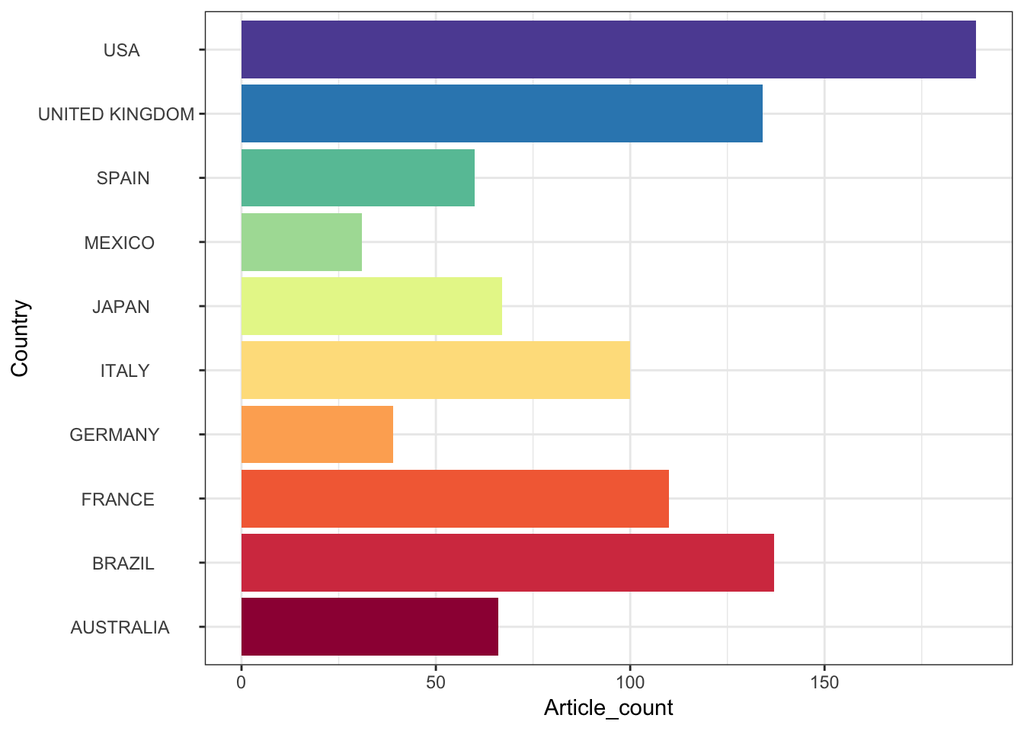

```r
#bar chart
df_count<-data.frame(Country=as.character(citations_ana.sum$MostProdCountries$`Country  `),Article_count=as.integer(citations_ana.sum$MostProdCountries$Articles))
ggplot(df_count, aes(Country, Article_count)) +
  geom_bar(stat = "identity",fill=brewer.pal(10, "Spectral")) +
  coord_flip() +
  theme_bw()
```

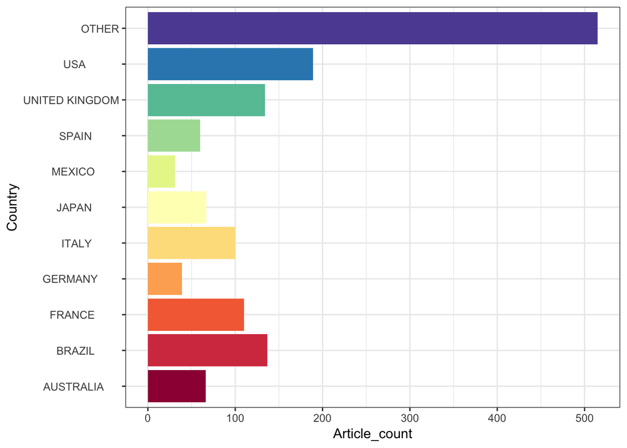

```r
#with everyone else category
vec<-as.data.frame(citations_ana$Countries,stringsAsFactors = F) %>% filter(!Tab %in% trimws(as.character(df_count$Country),which = c("both", "left", "right"))) %>% select(.,Freq) %>% sum()
vec2<-data.frame(Country='OTHER',Article_count=as.integer(vec))
df_count<-rbind(df_count,vec2)

ggplot(df_count, aes(Country, Article_count)) +
  geom_bar(stat = "identity",fill=brewer.pal(11, "Spectral")) +
  coord_flip() +
  theme_bw()
```

```r
#write it out as a table
write.table(citations_ana.sum$MostProdCountries,'TopProducingCountriesForAllozymeGeneralSearch',row.names=F,quote=F,sep='\t')
```

We are interested in how many papers are produced per year so we can see that in the summary file. I have put a few graph options in here to get you started on some ideas.

```r
#citations_ana.sum$AnnualProduction
citations_ana.sum$AnnualProduction %>% mutate(cumsum=cumsum(Articles),cumper=cumsum(Articles)/sum(Articles)*100)
```

```
##    Year    Articles cumsum     cumper
## 1     1966        1      1   0.066357
## 2     1968        1      2   0.132714
## 3     1973        1      3   0.199071
## 4     1974        1      4   0.265428
## 5     1975        3      7   0.464499
## 6     1977        2      9   0.597213
## 7     1978        4     13   0.862641
## 8     1979        3     16   1.061712
## 9     1980        6     22   1.459854
## 10    1981        3     25   1.658925
## 11    1982        9     34   2.256138
## 12    1983        7     41   2.720637
## 13    1984       11     52   3.450564
## 14    1985        5     57   3.782349
```

[output cut: 33 more lines]

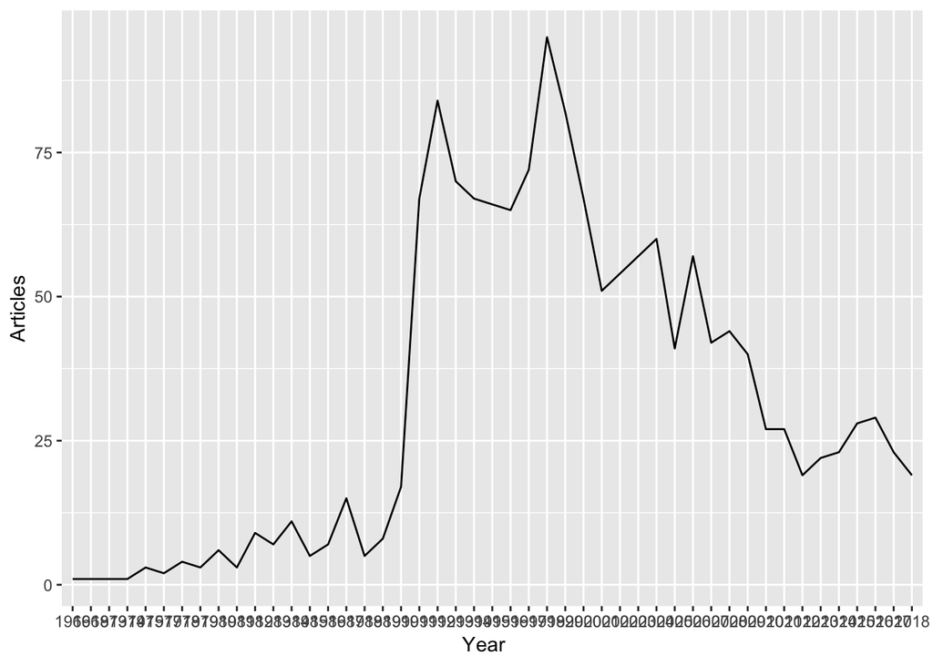

```r
#basic line graph
ggplot(citations_ana.sum$AnnualProduction, aes(`Year   `,Articles, group=1)) +
  geom_line(aes(`Year   `,Articles))
```

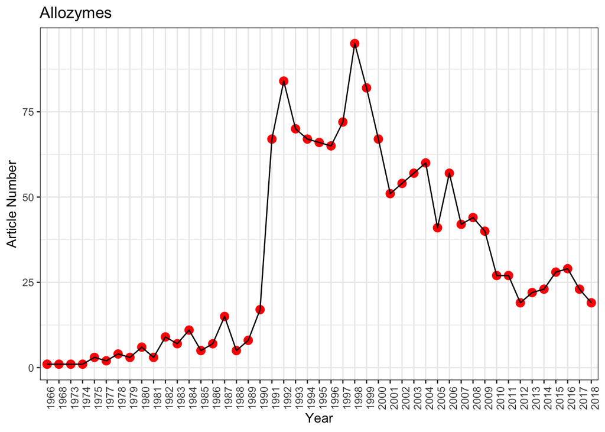

```r
ggplot(citations_ana.sum$AnnualProduction, aes(`Year   `,Articles, group=1)) +
  geom_point(aes(citations_ana.sum$AnnualProduction$`Year   `,citations_ana.sum$AnnualProduction$Articles), size = 3,colour='red') +
  geom_line(aes(`Year   `,Articles)) +
  labs(title="Allozymes",x='Year', y='Article Number', fill="Subset") +
  theme_bw() +
  theme(axis.text.x = element_text(angle = 90, hjust = 1))
```

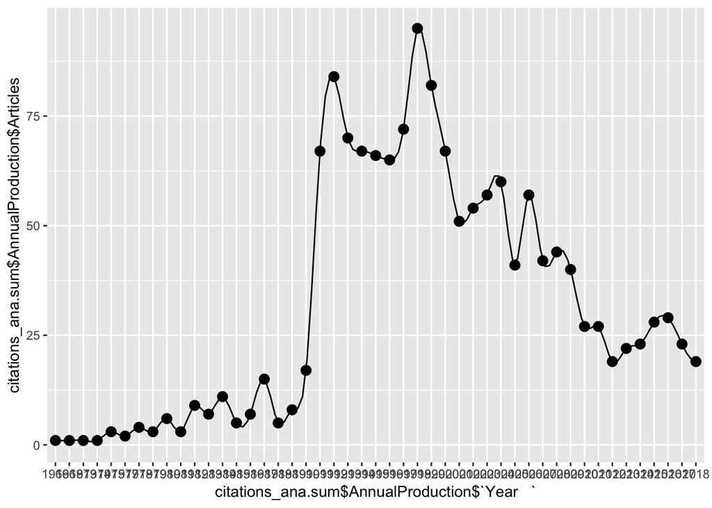

```r
#create some splines to smooth the curve
spline_int <- as.data.frame(spline(citations_ana.sum$AnnualProductio$`Year   `, citations_ana.sum$AnnualProduction$Articles))

#add the splines in
ggplot(citations_ana.sum$AnnualProduction) +
  geom_point(aes(citations_ana.sum$AnnualProduction$`Year   `,citations_ana.sum$AnnualProduction$Articles), size = 3) +
  geom_line(data = spline_int, aes(x,y))
```

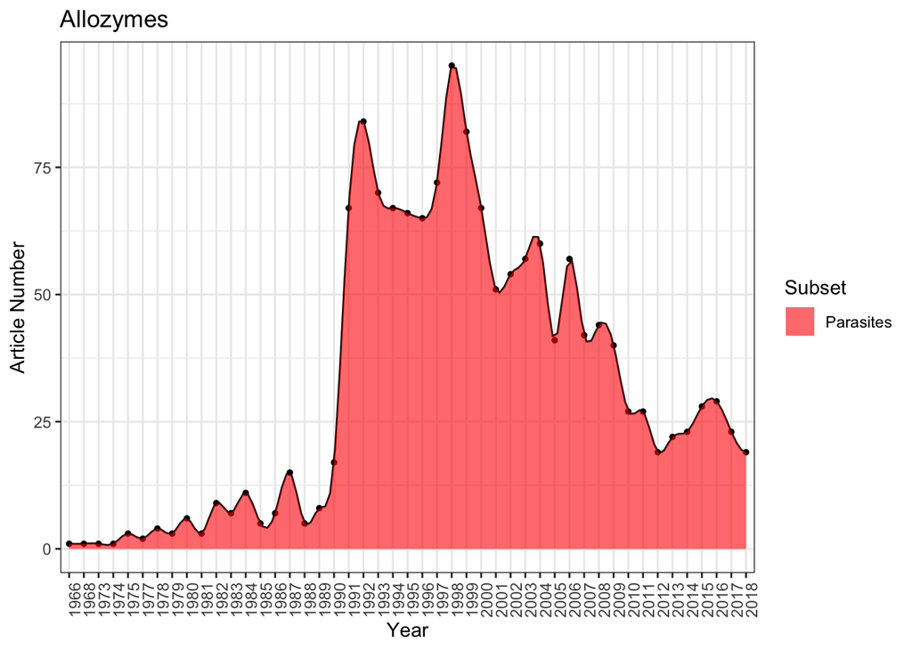

```r
#just make it look a bit prettier
ggplot(citations_ana.sum$AnnualProduction) +
  geom_point(aes(citations_ana.sum$AnnualProduction$`Year   `,citations_ana.sum$AnnualProduction$Articles), size = 1) +
  geom_line(data = spline_int, aes(x,y)) +
  geom_area(data = spline_int, aes(x,y,fill='red'),alpha=0.6) +
  theme_bw() +
  theme(axis.text.x = element_text(angle = 90, hjust = 1)) +
  labs(title="Allozymes",x='Year', y='Article Number', fill="Subset") +
  scale_fill_manual(labels = "Parasites", values = alpha("red",.6))
```

We also want to do some word clouds. There is two ways to use word clouds. The first way is that we treat every word in the key word list individually. There is two types of key words. The first is the Author Keywords, the second is the ‘Keywords-Plus’ which is generated by WoS. Im going to use the Author Keywords but commented in is the lines for the ‘Keywords-Plus’.

For author keywords: citations_ana.sum$MostRelKeywords$\`Author Keywords (DE) ` For WoS keywords: citations_ana.sum\$MostRelKeywords$`Keywords-Plus (ID) `

Here we will build a new dataframe of our keywords and filter out the stuff we dont want before creating a corpus. Which is a sort of list used by text mining packages in R. Im not totally sure what is special about it - but we need it!

```r
#change the summary to return more hits (before it was just 10 here it is 50)
citations_ana.sum <- summary(object = citations_ana, k = 50, pause = FALSE)
```

```
##
##
## Main Information about data
##
##  Documents                             1507
##  Sources (Journals, Books, etc.)       429
##  Keywords Plus (ID)                    3835
##  Author's Keywords (DE)                3011
##  Period                                1966 - 2018
##  Average citations per documents       30.1
##
##  Authors                               4639
##  Author Appearances                    7058
##  Authors of single authored documents  69
##  Authors of multi authored documents   4570
```

[output cut: 394 more lines]

```r
#careful with this table the biblio function has built a table which has two columns named 'Articles'
head(citations_ana.sum$MostRelKeywords)
```

```
##   Author Keywords (DE)      Articles    Keywords-Plus (ID)     Articles
## 1 ALLOZYMES                       83 IDENTIFICATION                 179
## 2 TRYPANOSOMA CRUZI               75 DIFFERENTIATION                110
## 3 ISOENZYMES                      53 POPULATIONS                    103
## 4 ISOENZYME                       52 DNA                             87
## 5 ELECTROPHORESIS                 42 CHAGAS-DISEASE                  78
## 6 POPULATION GENETICS             40 STRAINS                         78
```

```r
colnames(citations_ana.sum$MostRelKeywords)
```

```
## [1] "Author Keywords (DE)     " "Articles"                  "Keywords-Plus (ID)    "    "Articles"
```

```r
#get rid of punctuation and create data frame
forwordcloud<-as.data.frame(cbind(as.character(trimws(citations_ana.sum$MostRelKeywords$`Author Keywords (DE)     `, which = c("both", "left", "right"))),citations_ana.sum$MostRelKeywords[2]),stringsAsFactors=FALSE)
colnames(forwordcloud)<-c('keyword','count_papers')

#if we want to plot 'Keywords-Plus (ID)'
#forwordcloud<-as.data.frame(cbind(as.character(trimws(citations_ana.sum$MostRelKeywords$`Keywords-Plus (ID)    `, which = c("both", "left", "right"))),citations_ana.sum$MostRelKeywords[4]),stringsAsFactors=FALSE)

#dataframe:
head(forwordcloud)
```

```
##               keyword count_papers
## 1           ALLOZYMES           83
## 2   TRYPANOSOMA CRUZI           75
## 3          ISOENZYMES           53
## 4           ISOENZYME           52
## 5     ELECTROPHORESIS           42
## 6 POPULATION GENETICS           40
```

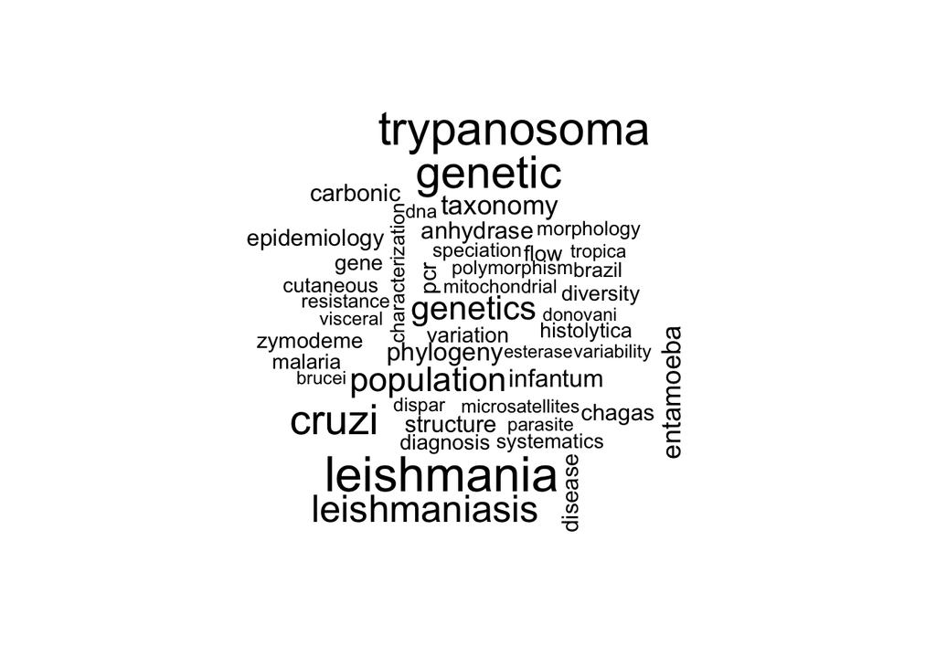

```r
#we want to drop the keywords we searched for from our dataframe
forwordcloud<-forwordcloud %>% filter(.,keyword!='ALLOZYMES',keyword!='ALLOZYME',keyword!='ALLOZYME ELECTROPHORESIS',keyword!='ALLOZYME VARIATION',keyword!='ISOENZYME ELECTROPHORESIS',keyword!='ISOENZYMES',keyword!='ISOENZYME',keyword!='ELECTROPHORESIS',keyword!='ISOZYME',keyword!='ISOZYMES',keyword!='RAPD')

#create corpus
forwordcloud.Corpus<-Corpus(VectorSource(forwordcloud[rep(row.names(forwordcloud), forwordcloud$count_papers), 1]))

#can use the function inspect to display the information on the corpus
#inspect(forwordcloud.Corpus)

#we dont have any special characters but we could remove funky characters if we have them
#these will throw a warning but dont worry they dont mean anything here-its not dropping documents its because I used a vector source for the corpus and for whatever reason that generates a warning
#forwordcloud.Corpus<- tm_map(forwordcloud.Corpus, removePunctuation)
#forwordcloud.Corpus <- tm_map(forwordcloud.Corpus, removeNumbers)
#forwordcloud.Corpus <- tm_map(forwordcloud.Corpus, stripWhitespace)
#forwordcloud.Corpus <- tm_map(forwordcloud.Corpus, remove_stopwords) #with package 'tau'
#forwordcloud.Corpus <- tm_map(forwordcloud.Corpus,content_transformer(tolower))
#qdap package offers other cleaning functions if we need them

#create wordclouds
wordcloud(forwordcloud.Corpus,scale=c(2.2,.6))
```

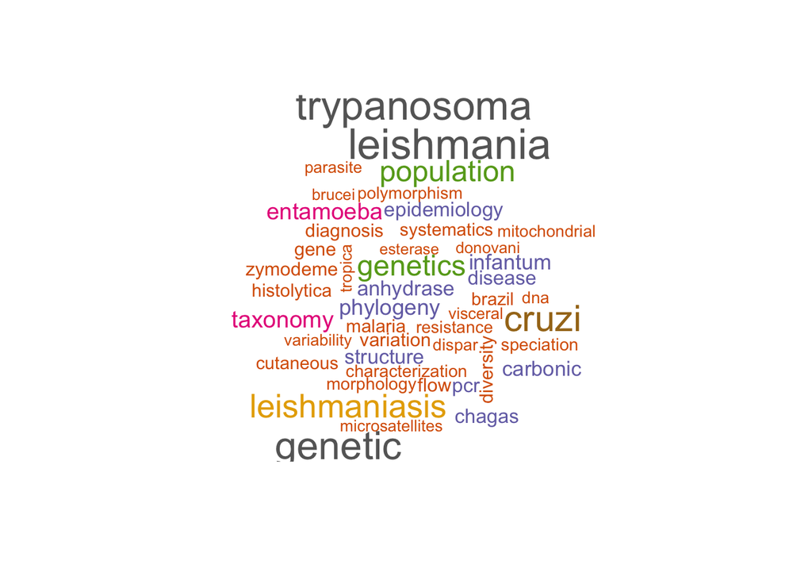

```r
#make it pretty-look up brewer.pal for colour pallets https://www.nceas.ucsb.edu/~frazier/RSpatialGuides/colorPaletteCheatsheet.pdf

wordcloud(forwordcloud.Corpus,colors=brewer.pal(8, "Dark2"),scale=c(2.2,.6))
```

You can see that ‘genetic’ and ‘genetics’ come up. You can try to use the stemming function to look for the root of the word but I found this a bit ugly and ended up doing it by hand.

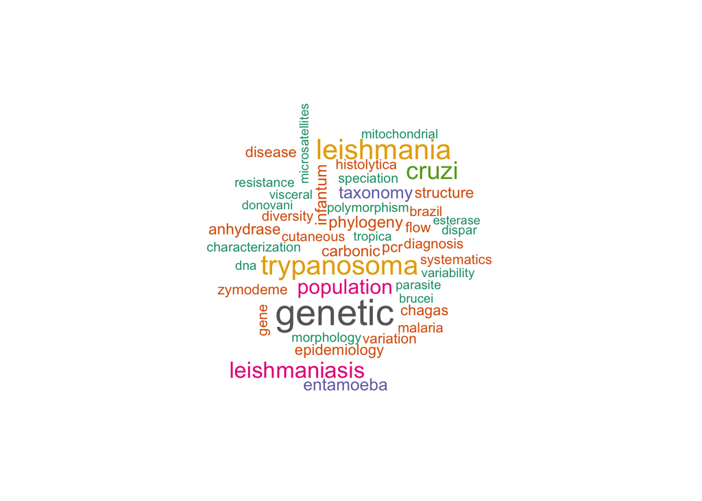

```r
#steming function
#forwordcloud.Corpus <- tm_map(forwordcloud.Corpus,content_transformer(tolower))
#forwordcloud.doc<- tm_map(forwordcloud.Corpus, stemDocument, "english")
#wordcloud(forwordcloud.doc,colors=brewer.pal(8, "Dark2"))

#code to reduce redundancy by hand
forwordcloud<-forwordcloud %>%  mutate(fixkeyword=sub("GENETICS", "GENETIC", keyword))

forwordcloud.Corpus<-Corpus(VectorSource(forwordcloud[rep(row.names(forwordcloud), forwordcloud$count_papers), 3]))

wordcloud(forwordcloud.Corpus,colors=brewer.pal(8, "Dark2"),scale=c(2.2,.6))
```

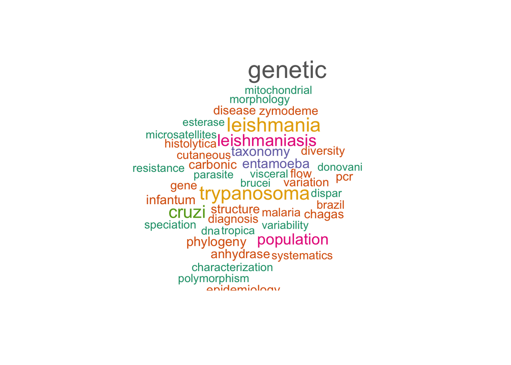

```r
#you can change the percentage that are rotated with the rot.per call
wordcloud(forwordcloud.Corpus,colors=brewer.pal(8, "Dark2"),rot.per=0,scale=c(2.0,.8))
```

The second way to make a word cloud is to consider the whole phrase a word. I think this makes more sense but it may not be as nice to look at.

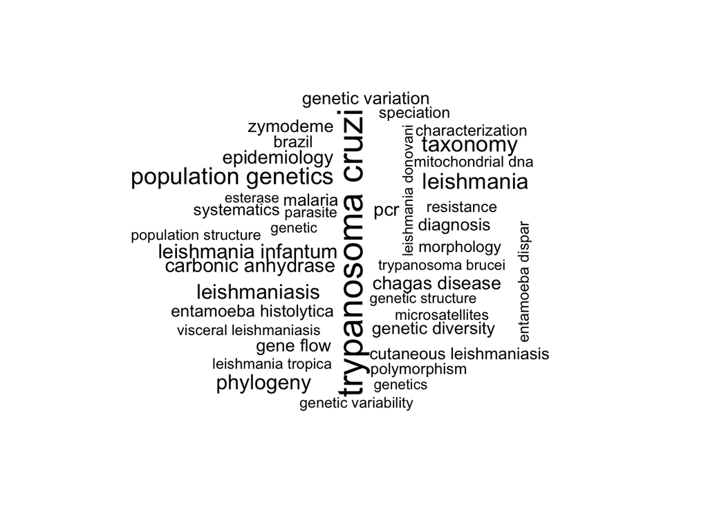

```r
wordcloud(tolower(forwordcloud$keyword),as.numeric(forwordcloud$count_papers), colors="black",scale=c(2.1,.6))
```

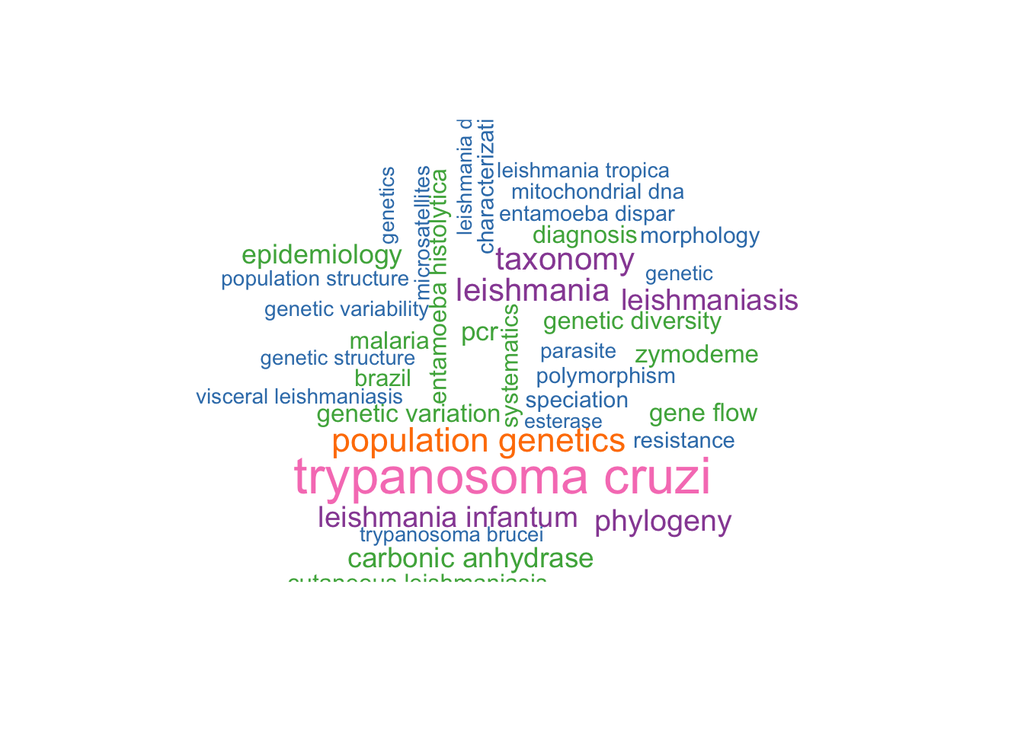

```r
#colours and font
wordcloud(tolower(forwordcloud$keyword),as.numeric(forwordcloud$count_papers), colors=brewer.pal(8, "Set1"),scale=c(2.1,.6))
```

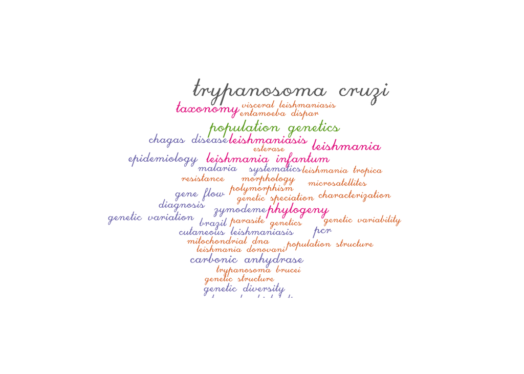

```r
wordcloud(tolower(forwordcloud$keyword),as.numeric(forwordcloud$count_papers), colors=brewer.pal(8, "Dark2"),vfont=c("script","bold"),rot.per=0,scale=c(2.1,.6))
```

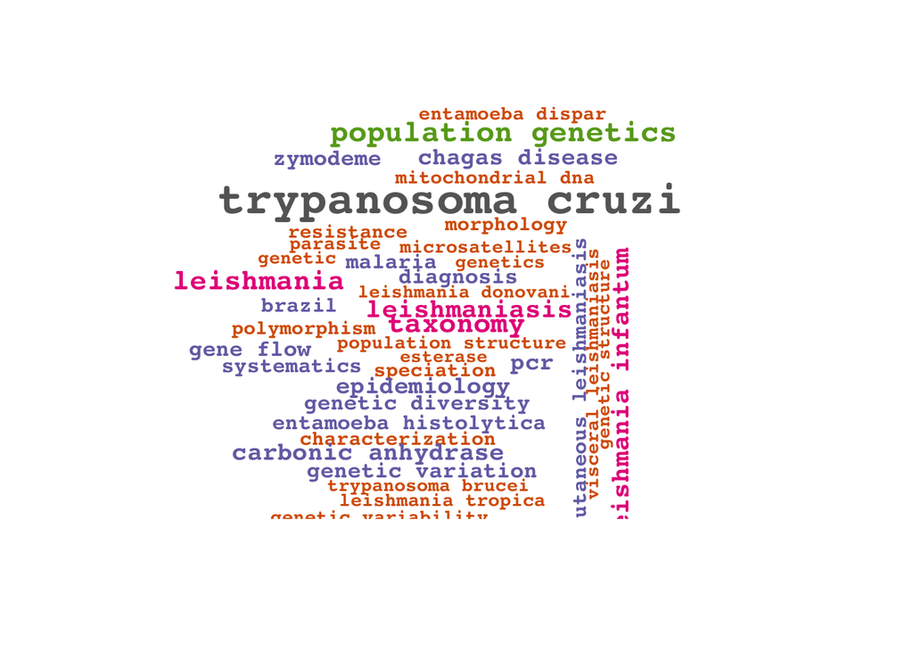

```r
wordcloud(tolower(forwordcloud$keyword),as.numeric(forwordcloud$count_papers), colors=brewer.pal(8, "Dark2"),family = "mono",font = 2,scale=c(2.1,.6))
```

# Okay we have our parasite plots but really what we want is to compare these to the general search terms

This first set will be if you are comparing parasite searches that you downloaded 500 at a time to the publication per regions and publication per year files that you downloaded from the WoS website for the general searchers.

# Comparing parasites to general searches via API download